# Efficient R

Thomas Riebenbauer, Michaela Dvorzak, JOANNEUM RESEARCH

02 Oktober, 2023, v2.0.0

**Feedback and contributions**

Your feedback is very valuable to enhance this document. If you have remarks or want to give feedback please contact:

- Michaela Dvorzak, michaela.dvorzak@joanneum.at

# 1 Philosophy

This document serves as a basis for “efficient working with R” and gives recommendations to make data analysis with R easier, more efficient, consistent and reproducible:

- Standard definition for structuring files to make it easier to find stuff again (others as well as “future-you”)
- Keep things together, which belong together by content.
- Consistent work with R (templates and coding standard)
- Make data analysis with R reproducible
- Share tips and tricks for working with R(studio)

Note that exceptions are always OK, if there are good reasons for.

# 2 Project structure

We strongly recommend to use the existing project structure of the “Schwarzes Brett” for all projects since folders are accessible to all project collaborators. The JR-POL project folder contains all organizational, legally and economically relevant documents and notes, from which the current status and progress of a project is recognisable. The project leader is responsible for the preparation and processing of the project folder. For details, see the [QM-Handbuch, Ablage von Projektunterlagen](https://dms.joanneum.at/lldefesso/livelink.exe?func=ll&objId=6777123&objAction=browse&viewType=1).

The project folder is organized as follows:

```
##    levelName                           wd_name
## 1  "root"                              NA
## 2   ¦--01 Projektstammdaten            NA
## 3   ¦   ¦--01 Angebotsunterlagen       NA
## 4   ¦   ¦   ¦--1 Vorangebotsunterlagen NA
## 5   ¦   ¦   °--2 Angebot               NA
## 6   ¦   ¦       °--Angebotsvorlagen    NA
## 7   ¦   ¦--02 Beauftragung             NA
## 8   ¦   ¦--03 sonstige Verträge        NA
## 9   ¦   °--04 Anzahl_Rechnungen        NA
## 10  ¦--02 Projektablauf                NA
## 11  ¦   ¦--01 Planungsunterlagen       NA
## 12  ¦   ¦--02 Reviews und Prüfungen    NA
## 13  ¦   ¦--03 Kostenverfolgung         NA
## 14  ¦   ¦--04 Projektabnahme           NA
## 15  ¦   °--05 Reklamationen            NA
## 16  ¦--03 Korrespondenz                NA
## 17  ¦   ¦--01 Korrespondenz            NA
## 18  ¦   °--02 Besprechungen            NA
## 19  ¦--04 Lieferung an Auftraggeber    NA
## 20  °--05 Arbeitsverzeichnis           NA
```

- `--01 Projektstammdaten` contains all documents relating to the proposal such as the proposal itself, the project calculation, the bidding documents, statements of costs, contracts for work labor as well as information on project team members (including external project partners).
- `--02 Projektablauf` comprises all planning documents (e.g., tasks and system specifications, etc.), reviews (i.e., review protocols, deviation reports), cost monitoring etc.
- `--03 Korrespondenz` contains documents relating to the project correspondence such as e-mails, faxes and letters, as well as meeting notes.
- All documents sent or handed over to the customer are stored in the folder `--04 Lieferung an Auftraggeber`.
- The folder `--05 Arbeitsverzeichnis` (working directory) contains the actual project work and will be described in the following section.

## 2.1 Working directory: folders & files

The structure of the working directory and its corresponding folder content are described below.

```
##    levelName                wd_name
## 1  "root"                   NA
## 2   ¦--01_data              NA
## 3   ¦   ¦--01_original      NA
## 4   ¦   °--02_work          NA
## 5   ¦--02_work              NA
## 6   ¦   °--R_projname       NA
## 7   ¦--03_results           NA
## 8   ¦   ¦--01_output        NA
## 9   ¦   ¦   °--tmp          NA
## 10  ¦   ¦--02_reports       NA
## 11  ¦   °--03_presentations NA
## 12  ¦--04_literature        NA
## 13  °--05_other             NA
```

Note that this structure is always **expandable** specific to a project, i.e., subfolders for additionally structuring your files are possible in all directories.

**01_data/**

- 01_original
- 02_work

This folder contains all data that are used in a project. Original (read only!) data are stored in the subfolder `01_original` and should not be modified in any way. Processed/edited data (e.g., prepared data and *.rds* files, generated in R, Excel etc.) are stored in the subfolder `02_work`.

**02_work/**

- R_projname

In a nutshell, this folder holds all “work files”. It contains the R-project directory `R_projname` (where *projname* is the (short) name of the corresponding project) which includes your *.Rproj*-file, all R code and further R-related files such as your *.Rprofile*-file and several templates which are described below. See section How to start for details on creating a new Rstudio-project.

We suggest to use the same structure when using other software such as SAS or SPSS (e.g., `SAS_projname`).

We further recommend to use a **consistent workflow** when working with R (or a comparible) software. This workflow involves

- an initialization file for your project (*00_init.R*) to specify working directories, required packages and general settings
- a file which collects all functions which are used within a project (*00_functions.R*)
- (separate) data preparation files (e.g., *01_data_prep.R*) to prepare your data prior to analysis (do **not** mix data preparation steps with code to analyse your data)
- data analysis files (e.g., *02_data_analysis.R*)

Note that it is recommended to prefix file names with numbers for structuring R (or SAS) file names. The (consecutive) numbering is project specific and arbitrary.

**03_results/**

- 01_output/tmp
- 02_reports
- 03_presentations

This folder holds all project results. In detail, `01_output` contains figures and tables (e.g., csv-files genereated in R) where the additional subfolder `tmp` can be used to store temporary results. Subfolders (e.g. to save figures and tables separately) can be created for reasons of clarity, depending on a project extent.  
All reports (i.e., progress reports, final reports) are saved in the subfolder `02_reports`. We suggest to clearly identify the (very last) version of the final report by adding the supplemenet “_final” (e.g., “xxx_final.docx” or “xxx_final.pdf”) to the document name.  
As the name suggests, presentation slides (such as .ppt or .pdf files) are stored in the folder `03_presentations`. Again, the final version of the slides should be highlighted by the supplement “_final” in the document name.

**04_literature/**

All sources of literature used within a project are stored in the folder `04_literatrue`.

**05_other/**

This folder contains all **project work** (**!**) related documents which do not fit into the previous project folders.

## 2.2 Templates

For working with R within a project several templates are provided to make data analysis with R easier, more consistent and more reproducible. It is also intended to [stop the working directory insanity](https://gist.github.com/jennybc/362f52446fe1ebc4c49f).

An important part of the concept are **working directories**, which are defined in *00_init.R*. There are two important directories:

1. The R-project directory `wd_rproj`: This is the directory holding your *.Rproj*-file and your *.Rprofile*-file. Typically also your code lies here. Subfolders for structuring your files are allowed. The path will be auto-generated.
2. The project directory `wd_proj`: This is the directory, where the above defined folder structure is expected. Thus `wd_rproj` is *typically* a subfolder. In any case, everything except R-code is expected corresponding to the above folder structure. `wd_proj` is tried to be auto-generated from the R-project directory.

When you want your R-code in a different place from the project folder, you may use the `project_directory` option of the *project.yaml*-file (see below).

*.Rprofile*

- Initialization file of the R-session being sourced when starting R
- *00_init.R* will be sourced, if it exists
- The project directory is searched and set.
- It creates and appends a *sessionInfo.log* file at the end of your Rstudio-session.
- Usually you only need to take care to not to remove it.
- You can also manually use the template-infrastructure by `source(".Rprofile"); .First()`.

*00_init.R*

- Initialization file for your project
- This file is designed to being sourced at project start. Here everything can be defined, that should be **globally available** for your project. The following is suggested:
  - Define all **working directories** as variables starting with `wd_` (hint: use `file.path()` to specify working directories/paths to load and save files!)
  - Load all needed **R packages**.
  - Source all **function**-files here.
  - Define here **general settings**, variables or similar code, which will be available for all other files.
  - Do not insert code which takes considerable time, as this file is loaded on each project startup.

*00_functions.R*

- File that contains all functions of your project
- If you feel to have too many functions for one file, you might of course create multiple function-files or even create a folder for your function files.

*project.yaml*

- Metafile according to the [yaml](https://en.wikipedia.org/wiki/YAML)-format with project information
- The following entries are currently defined:
  - `project_yaml_version`: the version of the yaml-file (do not modify!)
  - `project_directory`: optional parameter to set the project directory. The following values are allowed:
    - `NULL`, `NA` or empty: the project directory is dynamically generated based on the location of your code
    - a path: if a path is specified, this is taken as the project directory. You do this typically, if your project lies on a network drive, while your code is local. This is **recommended, when collaborating with git**.
  - `load_init`: `TRUE` or `FALSE` indicating, if the *init*-file should automatically be loaded on startup of the Rstudio-project
  - `load_files`: allows to define additional files to be loaded at project startup (order is considered)
  - `title`: Title of the project
  - `authors`: Author or authors of the project
  - `R_version`: expected R-version

The template structure will create and append a **sessionInfo.log** file at the end of your Rstudio-session. It records your R-session-info and your user information. This is for you to recapture what might have happened if something goes wrong. Usually you don’t need to track this file with git.

## 2.3 How to start

Working with **Rstudio-projects** is strongly recommended. For creating a new Rstudio-project, please do the following:

1. You need to have some packages installed, to use all features. The following code tests for those packages and installs them, if needed:

```r
if (!require("yaml")) install.packages("yaml")
if (!require("tidyverse")) install.packages("tidyverse")
if (!require("rmarkdown")) install.packages("rmarkdown")
if (!require("praise")) install.packages("praise")
if (!require("data.tree")) install.packages("data.tree")
if (!require("rprojroot")) install.packages("rprojroot")
if (!require("devtools")) install.packages("devtools")
```

2. Copy the folder structure (working directory including templates) stored in `/.../07 Projekte/_R-Struktur_Musterordner/` (Schwarzes Brett) to your desired destination (network drive project folders are recommended).
3. Rename the folder `02_work/R_projname` by replacing *projname* with the (short) name of your project (lower case, separated by “_“, no special characters).
4. Open the *project.yaml*-file and edit it according to your project.
5. Open Rstudio.
6. File -> New Project -> Existing Directory
7. Set the project directory to the folder renamed in step 3. Press “Create Project”.

### 2.3.1 Collaborating

By default, the project assumes that all your relevant files are within the project directory you are currently in. For collaborating in projects, we recommend placing the project files on a shared directory (in our case: “pol_sb”). So please follow the following steps:

1. Create the project structure and the Rstudio project as described above.
2. Set the project directory (directory containing folder templates) in the *project.yaml*-file.  
   *Remark:* If the project directory is on a network drive, be sure to use the network-path NOT containting an associated drive letter.
3. Make your project a git project (see here).
4. For each person wanting to collaborate with, get a git-project copy (see here).  
   Remarks: Typically you want your git-project copy locally. You may also want to use the project structure to put your git-project copy into, although this is not needed.

Remember the following:

- You are working on a private copy of the files tracked with git.
- The data is loaded from the common project files (as specified in *project.yaml*) which is typically not local (!) but on the shared `pol_sb` directory. So you usally do not need any data to be stored locally.
- The results are saved in the common project folders.

## 2.4 Naming: Folders & files

We suggest to consider the following recommendations which (may) serve as a general guideline in structuring folder and file naming conventions to be consistent and descriptive in naming and organizing:

- Keep file and folder names short, but meaningful.
- English is the default language for naming folders and files. If one uses German, we strongly recommend to avoid Umlauts, especially for folder names. In any case, do not use special characters or whitespaces and stick to [a-z], [A-Z], [0-9], [_,-].
- Use lower case letters.
- Do not use “.” but the underscore “_” as element delimiter. Additionally, consider the following suggestions for folders and files:

**Folders**

- Prefix folders (and subfolders) with numbers for structuring, i.e., use “00_name” (exception: “02_work/R_projname”, etc.).
- Avoid long folder names. The maximum path length is 260. For details, see [here](https://stackoverflow.com/questions/26151365/long-path-filename-in-windows-makes-write-table-error-out-in-r).
- Do not use Umlauts (in project paths)!

**Files**

- Prefix files with numbers for structuring, i.e., use “00_name” (exception: README, meta files, etc.).
- Order the elements in a file name in the most appropriate way to retrieve the record, e.g., include the current date in the file name if there are several versions of the same document.

## 2.5 Special cases

When working and collaborating with the above defined project structure you may encounter special cases not covered so far. Therefore we tried to identify the most relevant special cases together with solutions:

### 2.5.1 Working outside the company network

It might happen, that you need to access your project from outside the company network (e.g. at a costumer). One option is to use VPN (provided by Rechenzentrum), but this is slow. VPN also does not work without internet. We identified some solutions for these situations:

- **Offline access (recommended)**: The company Windows versions should be equipped with the tool “Synchronisierugnscenter”. It let’s you define folders on shared drives which should be available offline. Windows saves the files on your local drive and syncs whenever your connected to the network. See [here (german)](https://www.pcwelt.de/ratgeber/Windows-7-Funktion-Offlinedateien-Netzwerkdaten-unter-Windows-7-lokal-synchronisieren-433646.html) for some details.  
  This approach let’s you access all your project files anytime and anywhere.  
  *Remark*: Please be aware that all offline available data needs local storage. So periodic relesae of offline access for not further needed data is recommeded. You can release offline versions via (german): “Synchoronisierungscenter” -> “Offlinedateien verwalten” -> “Offlinedateien anzeigen” -> Browse to to a folder to release -> right click -> “Offlinekopie löschen”
- **Brute force copy**: A very simple and robust way is to copy the whole folder structure (or at least all needed files) to your local drive. Of course you might need to adapt your project path.  
  The main drawback of this approach is that you have to move all relevant changes back to the network drive by yourself which might be time-consuming, especially in case of large data sets.
- **Saving the R workspace**: This issue might be easier in the special case where you only want to access R code and some results within R. A prerequisite for this approach is that you have your code local (e.g. as via git-collaboration). In this case you can load all relevant objects into the R workspace while connected to the network drive and save the workspace locally as *RDA*-file. This makes it possible to load the *RDA*-file offline and work with it. Of course, you do not have access to all network-project-folders (e.g. the results-folder) via this approach.

### 2.5.2 Splitting a project

Sometimes it is needed to split a project into different parts with separate R-projects. We recommend to choose one of the following two options depending on the specific project:

1. **Multiple R(studio)-projects**: If you need multiple R(studio)-projects which can share the same projects structure (e.g. data or results-folder), then this might be your way. Just create multiple R-project folders within the `02_work/`-folder. Each can be treated separately in a standard way as already described. Just pay attention that the projects might use the same project structure. So changes affect both R-projects.
2. **Multiple project structures**: If your project-subtasks are too independent, so that you want them to have different project-folder-structures, then this approach might suit to you. Wherever your project-folders and -files are stored, just create two folder structures side by side (with speaking names). The standard approach would be to create two folders within the `05 Arbeitsverzeichnis` folder side by side containing independent folder structures as described above.  
   This approach makes it possible to separate data, results and all other work-related documents.

### 2.5.3 Not working on default shared drive

For some reason, you might want/need to place your project files somewhere else than on the default shared drive (in our case “pol_sb”). In this case, we recommend leaving a file explaining your reasons and the location of your project files in `05 Arbeitsverzeichnis`. This should be accompanied by a shortcut to this location.

In any case, we recommend using some shared drive as your alternative location, as this makes collaboration and secure backups possible. For special needs, the Rechenzentrum is your friend :).

### 2.5.4 Working on R-Server

Luckily, we have an R-server (http://polv301.joanneum.at:8787) for doing calculations not on your personal computer. Unfortunately, it is not straight-forward to use the R-server along with our presented project structure. This is the case as we decided to keep the data as well as the results on our dedicated project-network-drive “pol_sb”. The issue is that it is difficult to access “pol_sb” from the R-server.

Our first-help approach would be to place your project structure on the R-server by following the “Not working on default shared drive” recommendation. This should make the rest of our concept work properly. The reason is that it is possible to access the R-server and it’s file system from your computer.

If you want to use this approach, please let us know, so that we can check out if it is possible to develop a standardized approach for all of us.

### 2.5.5 Missing “01_admin”?

Some people might be used to a folder named `01_admin` in their project folder. This folder was omitted since administrative and organisational files should go to the corresponding folders defined by our QM-system (see here). Instead, we created the folder `05_other` for all files not fitting in any other place. If you still miss `01_admin` or need it for any other reason, we recommend creating a folder `00_admin` but keep in mind that other persons (including future-you) need to find the files you created.

### 2.5.6 Using another programming language?

R is great and you can do nearly everything needed with R. If you do not know R well, learn it 🎓 (see section “Learn, learn, learn”). If you need/want to use another programming language, it’s easy to integrate it in our project structure. Just create a separate folder within `02_work/` containing your code as described before.

# 3 File versioning / git

Use [Git](https://git-scm.com/)-Versioning for the whole project folder. A *.gitignore*-template is provided to give a standard definition for ignoring files, which should not be versioned.

## 3.1 What is version control?

Here’s a short video introduction:

[video not shown]

## 3.2 Why version control?

Version control in general and especially git are nowadays standard tools for data science and statistics. Git is strongly recommended by many R professionals, as it makes working with code professional. The reason is that git helps you tracking your code, saving versions of your code, it makes collaboration easier and lets future-you know what you have done in the past. Furthermore, git is one of the core tools helping to make research reproducible (see section about reproducibility).

More reasons why to use git?

- Read a blog post about [Why you need version control](https://www.r-bloggers.com/why-you-need-version-control/).
- Git is [free and open source](https://git-scm.com/about/free-and-open-source).
- The popular open source hosting website [Github](https://github.com/) strongly bases on git.

## 3.3 How to start

Beside Rstudio-projects, working with [git](https://git-scm.com/) (a version control system) is strongly recommended. When working with git, a remote repository helps keeping track as well as sharing code. As JR-internal repository we use [Gitea](https://git.pol.joanneum.at/).

There are two variants for starting to work with git and Gitea:

### 3.3.1 Create your own git-project

To make your Rstudio-project a git-project (git needs to be installed and set up) do the following:

1. Rstudio menu bar -> Tools
2. Project Options
3. Git/SVN
4. Version control system
5. Choose “Git”
6. Make your first commit via Rstudio

For using Gitea do the following:

1. Create a new project on Gitea. Press “New Repository” and set project name to *R_projname*.
2. Open the shell from within Rstudio (tab Git -> gear-wheel (*More*) -> New Terminal).
3. Execute `git remote add origin <ssh_url_to_your_repo>` (copy from Gitea) (right mouse key -> Edit -> Insert).
4. If not yet done: Make your first commit via Rstudio.
5. Return to the terminal and execute `git push -u origin master` which “pushes” your first commit.

### 3.3.2 Get a git-project someone else created

1. Open Rstudio -> File -> New Project
2. Version Control -> Git
3. Paste the repository url (e.g., from Gitlab or Github or Gitea).
4. Browse to the folder, where the folder for the git-project should be stored.
5. Press “Create Project”.

### 3.3.3 Issues regarding network paths

On using git from Rstudio on Windows there are some issues regarding network paths Especially when opening an Rstudio project from a network path without an associated drive letter, you won’t be able to use git from withon Rstudio. So please consider:

- Open Rstudio projects located on a network drive from a path using an assciated drive letter (e.g. `"H:/07 Projekte/..."`).
- For setting network paths as project directories in the *project.yaml*-file, please use the path NOT containging the assciated drive letter (e.g. `"//rzjna01/pol_sb/07 Projekte/..."`).

## 3.4 Recommendations on working with Git

- Use meaningful commit messages.
- Comment related changes.
- Commit often.
- Version control is not a backup system.
- Agree on a (consistent) workflow with your collaborators.
- [Sourcetree](https://www.sourcetreeapp.com/) is a great visual tool helping you to grasp what happens. People also speak very positively about [GitKraken](https://www.gitkraken.com/)
- There are many great resources out there to help you working with git. Here are some selected:
  - The great [Atlassian tutorials](https://www.atlassian.com/git)
  - [Git Best Practices](https://sethrobertson.github.io/GitBestPractices/)
  - [Git questions and solutions](http://41j.com/blog/2015/02/common-git-screwupsquestions-solutions/)
  - The [git documentation](https://git-scm.com/documentation) itself
  - There are many helpful cheat-sheets. For example:
    - Basics and general recommendations from [GitTower](https://www.git-tower.com/blog/git-cheat-sheet/)
    - [Git for Subversion Users](https://www.git-tower.com/blog/git-for-subversion-users-cheat-sheet/)
    - The [Atlassian git cheat sheet](https://www.atlassian.com/git/tutorials/atlassian-git-cheatsheet)

## 3.5 For sophisticated git-users

- Sophisticated users may cover the whole project repository with git. In this case, using git bash (and optionally a GUI) is recommended. Be careful to version only files which make sense to cover by version control. Remember that JR network drives are backed up too.
- Sophisticated users may also use branching. If you want to learn about branching, [here](http://learngitbranching.js.org/)’s a great learning resource. There are different concepts for branching, which are linked here:
  - [Attlassian](https://www.atlassian.com/git/tutorials/comparing-workflows) have a good overview about different workflows.
  - Thea [feature workflow](https://gist.github.com/blackfalcon/8428401)
  - The [GitFlow](http://nvie.com/posts/a-successful-git-branching-model/) workflow
  - The [Github workflow](https://guides.github.com/introduction/flow/)

## 3.6 Further reading

- [Happy git and github for the useR](http://happygitwithr.com/): A great online book with basics and instructions about working with R and git.
- Awesome interactive learning of branching: http://learngitbranching.js.org/ (recommended with Chrome-browser) includes commands commit, branch, checkout, cherry-pick, reset, revert, rebase, merge

# 4 Efficient data analyis with R(Studio)

Efficient data analysis in our view is much about writing “good” code. It also means using tools (e.g. Rstudio and git) to help you manage your code. The goal is to enhance the process of producing high quality code (with focus on quality). Plus: it’s more fun 😋. In your opinion one important point is *reproducibility*. It means that your results should be reproducible by you, other people and future-you.

This section covers many tips and tricks about several aspects of coding especially with . Some are more general and some are very specific. Sometimes the also overlap, but this might help you to remined them 😉. In any case we strongly recommend to also read the general recommendations (e.g. *Writing “good” code*) and to consider them while coding.

By the way: The Coding Standard will help you on the way to efficient data analysis.

## 4.1 Writing “good” code

The following principles give some general outline on how to write “good code (source: [David Smith](http://blog.revolutionanalytics.com/2010/10/a-workflow-for-r.html)):

- **Transparency**: Logical organisation of units
  - Structures and organizes your code and your project in general.
  - Structure may need some time to start, but it will pay of. It will be easier for others to collaborate or work with your code as well as for yourself (present-you and future-you).
- **Maintainability**: Standardization, clear comments
  - Comment about why you do what.
- **Modularity**: DRY (don’t repeat yourself) Principle, Discrete units
  - Put global variables for your project on *00_init.R*.
  - Write functions for repeated tasks.
  - Write functions for single tasks (if a function does multiple things, think about splitting it).
  - When you happen to change the same thing in your code on different places, think about writing a function covering the task.
- **Portability**: Relative paths, minimize dependencies, dependencies are clear
  - Make code files as independent as possible.
  - Document dependencies (between files, software versions, etc.).
- **Reproducibility**: Easy to reproduce results
  - see section Reproducibility
- **Efficiency**: Easy to maintain and modify

### 4.1.1 Writing “good” R-code

Additionally here are some more specific tipps regarding writing “good” code with :

### 4.1.2 Best Practices for Scientific Computing

To write “good” data anylsis code, there’s a lot to learn from computer science. Here are some best practices for good scientifc computing ([source](http://journals.plos.org/plosbiology/article?id=10.1371/journal.pbio.1001745#s2)):

1. Write programs for people, not computers.
   1. A program should not require its readers to hold more than a handful of facts in memory at once.
   2. Make names consistent, distinctive, and meaningful.
   3. Make code style and formatting consistent.
2. Let the computer do the work.
   1. Make the computer repeat tasks.
   2. Save recent commands in a file for re-use.
   3. Use a build tool to automate workflows.
3. Make incremental changes.
   1. Work in small steps with frequent feedback and course correction.
   2. Use a version control system.
   3. Put everything that has been created manually in version control.
4. Don’t repeat yourself (or others).
   1. Every piece of data must have a single authoritative representation in the system.
   2. Modularize code rather than copying and pasting.
   3. Re-use code instead of rewriting it.
5. Plan for mistakes.
   1. Add assertions to programs to check their operation.
   2. Use an off-the-shelf unit testing library.
   3. Turn bugs into test cases.
   4. Use a symbolic debugger.
6. Optimize software only after it works correctly.
   1. Use a profiler to identify bottlenecks.
   2. Write code in the highest-level language possible.
7. Document design and purpose, not mechanics.
   1. Document interfaces and reasons, not implementations.
   2. Refactor code in preference to explaining how it works.
   3. Embed the documentation for a piece of software in that software.
8. Collaborate.
   1. Use pre-merge code reviews.
   2. Use pair programming when bringing someone new up to speed and when tackling particularly tricky problems.
   3. Use an issue tracking tool.

## 4.2 Reproducibility

Why reproducibility?

[video not shown]

(… because non-reproducibility is a nightmare)

Read about reproducibility:

- [Reproducible Research with R and Rstudio](https://github.com/christophergandrud/Rep-Res-Book) (available for download [here](https://englianhu.files.wordpress.com/2016/01/reproducible-research-with-r-and-studio-2nd-edition.pdf))
- [CRAN Task View on Reproducible Research](https://cran.r-project.org/web/views/ReproducibleResearch.html)
- [Reproducibility Guide](http://ropensci.github.io/reproducibility-guide/) by ROpenSci

### 4.2.1 Ten Simple Rules for Reproducible Computational Research

To be more general here are ten Simple Rules for Reproducible Computational Research ([source](http://journals.plos.org/ploscompbiol/article?id=10.1371/journal.pcbi.1003285)):

- Rule 1: For Every Result, Keep Track of How It Was Produced
- Rule 2: Avoid Manual Data Manipulation Steps
- Rule 3: Archive the Exact Versions of All External Programs Used
- Rule 4: Version Control All Custom Scripts
- Rule 5: Record All Intermediate Results, When Possible in Standardized Formats
- Rule 6: For Analyses That Include Randomness, Note Underlying Random Seeds
- Rule 7: Always Store Raw Data behind Plots
- Rule 8: Generate Hierarchical Analysis Output, Allowing Layers of Increasing Detail to Be Inspected
- Rule 9: Connect Textual Statements to Underlying Results
- Rule 10: Provide Public Access to Scripts, Runs, and Results

## 4.3 Reading and writing files

Reading and writing files is essential for analysing data, as it links your code to your data as well as to your results. We think that this connection should be made clear and reproducible by your code. Here are some practical tips to

- Use `file.path()` to generate paths to directories and files (instead of `paste()`)
- Treat raw data as read only (!). Save modified data extra.
- Save different steps of your data analysis. For example, save data at the end of files and read it again in other files. This helps separating your code and makes scripts more independent (see also “Design files for being sourced” above).
- Try to standardize your file format usage. Our recommendations are:
  - For code (and all other types of text files) use UTF-8 encoding.
  - Save your plots and graphics ans PNG (portable network graphic), which is usually good for web as well as reports and other documents.
  - If using csv, choose one format to stick with within a project. We recommend to either use
    - `read.csv` or `read.csv2` (or from the *readr*-package `read_csv` and `read_csv2`) for reading as well as
    - `write.csv` or `write.csv2` (or from the *readr*-package `write_csv` and coming soon `write_csv2`) for writing.

## 4.4 Working with RStudio

provides a lot of useful functionality, which is constantly growing. Here, some recommendations are given for efficiently using Rstudio.

### 4.4.1 General tips and tricks

RStudio is in general a very flexible tool offering a lot of tools to support programming. You probably know some tools like code completion, the package manager, the build in help, the environment pane and so on. If you’re interested in the basics, please have a look at:

- [RStudio IDE Cheat Sheet](https://www.rstudio.com/resources/cheatsheets/)
- [RStudio Webinars](https://www.rstudio.com/resources/webinars/): especially the Webinars “Programming” Part 1 to 3 cover the basics of working with RStudio
- The [RStudio IDE Support Webpage](https://support.rstudio.com/hc/en-us/sections/200107586-Using-the-RStudio-IDE): here you can read about different topics about using RStudio

Here we’ll focus on how Rstudio can help you working with code. The main starting point for this is the “Code”-menu:

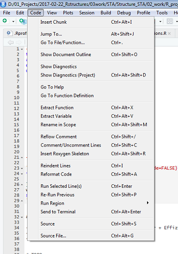

RStudio Code Menu

Based on the code menu the following list provides you with some selected functionalities and recommendations, which we find useful. In general, we recommend to have a look at what RStudio offers and to try out.

- **Keep RStudio up to date**: RStudios functionality is constantly growing. It also adapts to be compatible with new R-versions as well as important new packages. So stay up to date, e.g., via the “Help”-menu and “Check for Updates”. You might also use the [*installr*](https://github.com/talgalili/installr/)-package with the `install.RStudio()`-function (for Windows), see section Package recommendations for details.
- **Multiple lines**: RStudio lets you select and edit multiple lines at once. Just try to hold `Alt` and select some code with your Mouse. Now the cursor spans over multiple lines. Just try it :)
- **Document outline**: To give you an overview about your code, RStudio offers a document outline. There are two options to use it:
  1. In the code pane on the right you can let you show the structure of your code (or also R-markdown document). Just press `Ctr+Shift+O` or access it via the small “line”-icon on the top right of your code pane.
  2. Via a scrolable window on the bottom of your code pane. Just press on the text on the bottom to the right of the line:column numbers. The text always shows your actual section.

  The Coding Standard defines ways to structure your document (see also the Code Snippets compatible with RStudios document outline).
- **The most important shortcuts** in our opinion:

| Shortcut | What? | More details |
| --- | --- | --- |
| `Ctrl + Enter` | Run Line(s) | Run selected line(s) from script in the R console |
| `F1` | getting help | Just place your curser on some function from some package and press `F1` to show the corresponding help. |
| `F2` | showing the code | If you want to jump to the code of some function, just place your curser on the function name and press `F2`. |
| `Alt + Shift + K` |  | This shortcut shows an overview of all shortcuts. Keep in mind that you can also create your own shortcuts. |

- **Other really, really useful shortcuts**:

[output not shown]

- **Some further important topics** covered somewhere else:
  - Debugging in RStudio (see section Debugging)
  - Code coverage (see section Code coverage)
  - Profiling (see section Profiling)

The RStudio project menu helps you open your last opened projects. There you can also access the project options:

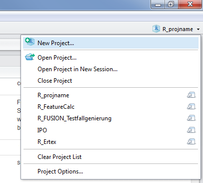

RStudio itself promotes regularly some tips and tricks. Here are some (older) blog posts (although the main points are already covered here):

- [December ’16 Tips and Tricks](https://rviews.rstudio.com/2016/12/09/december-16-rstudio-tips-and-tricks/)
- [January ’17 Tips and Tricks](https://rviews.rstudio.com/2017/01/27/january-17-rstudio-tips-and-tricks/)
- [February ’17 Tips and Tricks](https://rviews.rstudio.com/2017/03/03/february-17-tips-and-tricks/)
- [RStudio Tips, Tricks, and Shortcuts for Data Science](https://www.dataquest.io/blog/rstudio-tips-tricks-shortcuts/)

### 4.4.2 Code snippets

Code snippets are text macros that are used for quickly inserting common snippets of code. For example, the `fun` snippet inserts an R function definition:

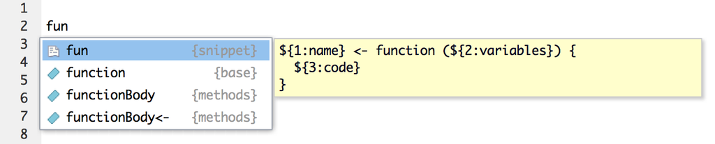

If you select the snippet from the completion list it will be inserted along with several text placeholders which you can fill in by typing and then pressing tab to advance to the next placeholder:

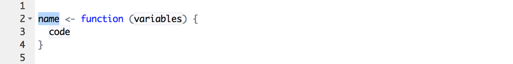

There are several useful code snippets available. See [here](https://support.rstudio.com/hc/en-us/articles/204463668-Code-Snippets) for more information (the above text is taken from this website).

#### 4.4.2.1 JR code snippets

To make more efficient use of our coding standard, we provide the following special code snippets:

- `file_head`, `file_head_auto`
- `fun_descr` for the header to describe functions
- `h1`, `h2` and `h3` for the headers for separating your code
- `sep1`, `sep2` and `sep3` for a simple separation line

For more examples about the JR code, please see the Coding Standard.

The code snippets are available via https://git.pol.joanneum.at/dvm/Rstructures/raw/branch/main/snippets/snippets.txt (accessible from within the JR network).

You can easily install the code snippets via the [`snippr`-package](https://github.com/dgrtwo/snippr).

First, you need to make your code snippets available with the `snippr`-package by editing it (only necessary once):

1. RStudio -> Tools -> Global Options -> Code -> Tab “Editing”
2. Click “Edit Snippets” on the bottom.
3. Stay at the R tab and enter a new line at the end of the code:

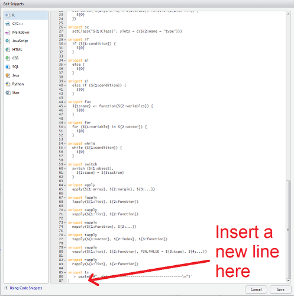

RStudio: edt code snippets. There are code snippets available for other languages than R.

Install the package:

```r
devtools::install_github("dgrtwo/snippr")
```

And now install the code snippets:

```r
snippr::snippets_install_url("https://git.pol.joanneum.at/dvm/Rstructures/raw/branch/main/snippets/snippets.txt")
```

After restarting Rstudio the code snippets will be available.

### 4.4.3 RStudio settings

RStudio offers a lot of settings to help you improve your coding workflow. Here we show you our recommended settings with short descriptions. If you have good reasons, feel free to use your own preferred settings. The settings are available via the menu “Tools” and “Global Options”. There’s an extra item for “Project Options”.

#### 4.4.3.1 General settings

Here you can choose between different installed R versions. 64-bit versions are preferred. The most important settings include:

- Never “Save work space to .Rdata on exit” (helps for reproducibility)
- “Automatically notify me of updates to Rstudio” (stay up tp date)

[figure not shown]

#### 4.4.3.2 Code Editing

[figure not shown]

RStudio Code Editing Options

#### 4.4.3.3 Code Display

[figure not shown]

RStudio Code Display Options

#### 4.4.3.4 Code Saving

Especially text encoding UTF-8 is recommended. This makes the usage of Umlauts much easier.

[figure not shown]

RStudio Code Saving Options

#### 4.4.3.5 Code Completion

Code completion is a very useful and powerful tool of Rstudio. It shows you a lot of available code and helps to improve your code writing on the go. It’s smart to give you suggestions based on what you’ve already written.

[figure not shown]

RStudio Code Completion Options

#### 4.4.3.6 Code Diagnostics

Code diagnostics gives you on the go information about what you’ve written. It analyses your coding style as well as basic code intactness. Our coding standard is compatible. [Here](https://support.rstudio.com/hc/en-us/articles/205753617-Code-Diagnostics) you’ll find more details and examples about code diagnostics with Rstudio.

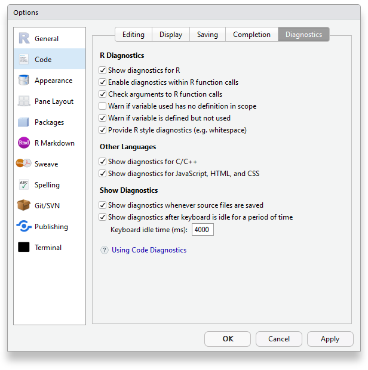

RStudio Code Diagnostics Options

#### 4.4.3.7 Project options

Project options give you control over specific projects. For some options you can use the default global options or specify specific options for your project. Most important we recommend to

- not restore .Rdata,
- not save work space to .Rdata on exit and
- to save history.

(of course, the default is fine, if you review your global settings)

[figure not shown]

RStudio Project Options

### 4.4.4 Other useful stuff

#### 4.4.4.1 Debugging

More often than you’ll want your code will break. And in too many cases, it won’t be obvious why it did break. Therefore, RStudio offers different features to help you find out what and where it happened. There’s an extra menu item with important commands for debugging. Here we recommend to set “Break in Code” on errors. This will show you directly where the code broke and what was the work space state. You’ll also be able to browse through the call stack.

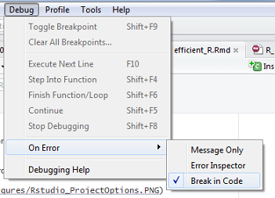

RStudio Debugging

For more information check out the following useful links:

- RStudio article about [Debugging with RStudio](https://support.rstudio.com/hc/en-us/articles/205612627-Debugging-with-RStudio)
- [Presentation about R software testing](https://www.is.uni-freiburg.de/ressourcen/algorithm-design-and-software-engineering-oeffentlicher-zugriff/11_softwaretesting.pdf) (Uni Freiburg)

#### 4.4.4.2 Profiling

RStudio’s code profiling (based on the package profvis) is a tool for helping you to understand how R spends its time and memory. It provides an interactive graphical interface for visualizing time and memory needed by your code. This helps you to find out where to optimize your code best. Code profiling is built in in Rstudio via an extra menu item:

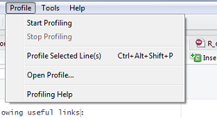

Rstudio Profiling Menu

For information on how to use profiling please refer to the help page: https://rstudio.github.io/profvis/

## 4.5 R markdown

R Markdown provides an authoring framework for data science. You can use a single R Markdown file to both

- save and execute code
- generate high quality reports that can be shared with an audience

R Markdown documents are fully reproducible and support dozens of static and dynamic output formats. This 1-minute video provides a quick tour of what’s possible with R Markdown:

[video not shown]

(the above text is taken from http://rmarkdown.rstudio.com/lesson-1.html)

R markdown is a very powerful tool for producing formatted documents in combination with R. It is possible to produce (among others) html, Word and PDF documents as well as websites, presentations, books or journal ready documents (see http://rmarkdown.rstudio.com/formats.html). You can use R notebooks, create dashboards and even integrate interactive content. To achieve this R markdown is based on the lightweight markup language [markdown](https://en.wikipedia.org/wiki/Markdown).

Want to read why R markdown is great? Read [Why I love R-Notebooks](https://www.rstudio.com/rviews/2017/03/15/why-i-love-r-notebooks/)

### 4.5.1 How to get started

We can recommend three excellent starting points for working with R markdown. Choose according to your learning preference:

1. “R Markdown Cheat Sheet”” and “R Markdown Reference Guide” (download from https://www.rstudio.com/resources/cheatsheets/)
2. [Introduction guide](http://rmarkdown.rstudio.com/lesson-1.html) on the R markdown website
3. Webinar [Getting Started with R Markdown](https://www.rstudio.com/resources/webinars/getting-started-with-r-markdown/) (about one hour)

### 4.5.2 Tips for working with R markdown

- R markdown is fully integrated in RStudio, so working with RStudio is recommended.
- R markdown documents are built to work as independent files. Thus, knitting an R markdown file starts with an empty environment:
  - Data and R-files have to be loaded within the R markdown file itself.
  - R markdown files use the directory they are saved in as working directory. This may be an issue when loading files or data. As working with relative paths is recommended (and `setwd()` is advised against), we recommend using the package [rprojroot](https://krlmlr.github.io/rprojroot/). See the packages section for more details.
- [Parameterized Reports](http://rmarkdown.rstudio.com/developer_parameterized_reports.html): R Markdown documents can optionally include one or more parameters. Parameters are useful when you want to re-render the same report with distinct values for various key inputs.

### 4.5.3 Rendering .R files

R scripts can be rendered. Basically that means, that you can do much of what you can do with R markdown also with R scripts. RStudio offers an option to compile every R script into HTML, PDF, or MS Word format:

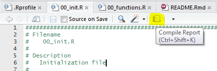

RStudio: compile notebook

Adding displayed text in the output, modifying the output, creating chunks, adapting the output format and so on is done through [roxygen2](https://cran.rstudio.com/web/packages/roxygen2/index.html) style comments (i.e. `#'`).

For further information, we recommend these resources:

- [Compiling Reports from R Scripts](http://rmarkdown.rstudio.com/articles_report_from_r_script.html)
- [Render an R script](http://happygitwithr.com/r-test-drive.html)

## 4.6 Testing R Code

Code testing is important and should be something that you do all the time. The R package testthat is a new testing framework which makes code testing as easy as possible. It provides several functions to describe what you *expect* a function to do, including catching errors, warnings as well as messages. Once defined, you can re-run the tests automatically as you change your code or tests. For a detailed description, see

- [Paper](https://journal.r-project.org/archive/2011-1/RJournal_2011-1_Wickham.pdf) about testthat
- [“R Packages” chapter](http://r-pkgs.had.co.nz/tests.html) about testing
- [Book: Testing R Code](https://www.crcpress.com/Testing-R-Code/Cotton/p/book/9781498763653)

### 4.6.1 Code coverage

Code coverage gives you information about which part of your code is covered by unit tests and which is not. Our package recommendation covr is written by RStudio’s Jim Hester (and supported by the [R Consortium](https://wiki.r-consortium.org/view/Code_Coverage_Tool_for_R)). It is very simply to apply code coverage. Especially for package, it’s recommended. There are also websites like [Codecov.io](https://codecov.io/) to help automating code coverage (especially in combination with Continuous Integration like [Travis-CI](https://travis-ci.org/)).

For more information, here are some useful links:

- [covr Github page](https://github.com/jimhester/covr)
- [Rstudio webinar about covr](https://www.youtube.com/watch?v=wP82XSFEiYs)

## 4.7 Package mangagement

In general, packages are installed through the function `install.packages()`. This installs the newest available package version. If you want to install an older package version you can use `install_version()` from the `devtools` package. But these packages are installed globally on your computer. If you want to use packages specifically for a project or manage your packages in general, this section will provide you with some solutions.

### 4.7.1 Why package dependency management

R package dependencies can be frustrating. Have you ever had to use trial-and-error to figure out what R packages you need to install to make someone else’s code work–and then been left with those packages globally installed forever, because now you’re not sure whether you need them? Have you ever updated a package to get code in one of your projects to work, only to find out that the updated package makes code in another project stop working? (source: https://rstudio.github.io/packrat/)

### 4.7.2 Solutions

There are two main solutions (i.e. R packages) for package dependency management:

1. [`packrat`](https://rstudio.github.io/packrat/)
   - packrat is flexible and powerful.
   - Supports non-CRAN packages (e.g. github).
   - Allows mix-and-matching package versions.
   - Requires shipping all package source.
   - Requires recipients to build packages from source.
2. [`checkpoint`](https://github.com/RevolutionAnalytics/checkpoint/wiki)
   - Checkpoint is simple.
   - Allows CRAN packages only.
   - Reproducibility from one script.
   - Simple for recipients to reproduce results.
   - Only allows use of CRAN packages versions that have been tested together.
   - Relies on availability of MRAN.
   - Allows only packages from one specific date (no mixing).

### 4.7.3 Checkpoint

Here is an example code for using `checkpoint`, which can be inserted in *00_init.R*:

```r
# R-version (the project is created with):
R_version <- getProjDetails("R_version") # e.g. "3.3.0"

# use checkpoint
checkpointsnapshotDate <- "2016-07-09" # (set once and do not change again)
checkpointLocation <- "~/R/win-library/" # where to store the packages
checkpoint::checkpoint(
  snapshotDate       = checkpointsnapshotDate,
  R.version          = R_version,
  checkpointLocation = checkpointLocation,
  project            = wd_rproj,
  scanForPackages     = TRUE
  )
# see the installed packages
installed.packages()[, "Package"]

# for more information see:
# https://cran.r-project.org/web/packages/checkpoint/vignettes/checkpoint.html
```

Running into problems by using checkpoint with knitr (or R markdown) and RStudio? [This article](http://blog.revolutionanalytics.com/2017/04/using-checkpoint-with-knitr-and-rstudio.html) might help.

### 4.7.4 Packrat

`packrat` is not used by simply adding code to your scripts. You must initialize your project as a packrat project, which will create a folder storing all relevant information (package versions, package source, etc.). It is integrated in RStudio (see [here](https://rstudio.github.io/packrat/rstudio.html) for more information), to help you using it. For more information about setup see the [walkthrough guide](https://rstudio.github.io/packrat/walkthrough.html).

## 4.8 Package recommendations

Notes: Nearly all packages listed here are hosted on [CRAN](https://cran.r-project.org/). Nevertheless, many of the underneath provided links link to GitHub. This is as GitHub pages usually show quick intro READMEs with links to most relevant resources. Github also allows you to look at the source code.

- [data.table](https://github.com/Rdatatable/data.table/wiki): high-performance version of base R’s data.frame with syntax and feature enhancements for ease of use, convenience and programming speed
  - Want to learn more? Look at the official website http://r-datatable.com
  - The fastest way to learn data.table is https://www.datacamp.com/courses/data-analysis-the-data-table-way (by data.table authors)
  - There’s a dplyr backend for data.table provided by the dtplyr-package.
- [rex](https://cran.r-project.org/web/packages/rex/index.html) for construction of regular expressions (see also on [GitHub](https://github.com/kevinushey/rex))
- [rprojroot](https://github.com/r-lib/rprojroot/): This package helps accessing files relative to a project root. This might be especially helpful for working with R markdown documents.
- Packages to help formatting your code:
  - [formatR](https://yihui.name/formatr/)-package to automatically format R code
  - [lintr](https://github.com/jimhester/lintr#project-configuration) for checking coding standard
- Packages for working with Microsoft Word (`.docx`) and PowerPoint (`.pptx`) documents
  - [officer](https://davidgohel.github.io/officer/) lets R users manipulate Word and PowerPoint documents. In short, one can add images, tables and text into documents from R.
- htmlwidgets: provides a framework for easily creating R bindings to JavaScript libraries. There are several R packages based on htmlwidgets available to explore at [htmlwidgets.org](http://www.htmlwidgets.org/) (especially the gallery is great for getting an impression).
- The [fst](http://www.fstpackage.org/)-package is a package to store data frames on disk very fast and compressed. The package seems to be a great and faster way saving and loading of data frames (esp. compared to RDS and csv).
- [installr](https://cran.r-project.org/web/packages/installr/index.html) provides the function `updateR()` for updating R. This function…
  - Checks what is the latest R version. If the current installed R version is up-to-date, the function ends (returns `FALSE`).
  - If a newer version is available, the user is asked to read the NEWS of the latest R version.
  - If the user decides to update, the function will download and install the latest version.
  - Asks if all packages should be copied from the old/current to the newer R installation.
- strict: “The goal of strict to make R behave a little more strictly, making base functions more likely to throw an error rather than returning potentially ambiguous results.  
  `library(strict)` forces you to confront potential problems now, instead of in the future. This has both pros and cons: often you can most easily fix a potential ambiguity when you are working on the code (rather than in six months time when you’ve forgotten how it works), but it also forces you to resolve ambiguities that might never occur with your code/data.”

### 4.8.1 Tidyverse

[tidyverse](https://cran.r-project.org/web/packages/tidyverse/index.html) is an ecosystem of packages that use the concept of tidy data and tidy tools. The website http://tidyverse.org/ is as a good starting point. For source code of all tidyverse-packages see https://github.com/tidyverse.

- **Tidy data**: “Tidy datasets are easy to manipulate, model and visualize, and have a specific structure: each variable is a column, each observation is a row, and each type of observational unit is a table.” (Hadley Wickham (2014), “Tidy data”, Journal of Statistical Software 59 (10), p.1). The concept of tidy data is an attempt to make data analysis more consistent and thus easier to program, extend, understand and work with. More information can be found in the corresponding [article](http://vita.had.co.nz/papers/tidy-data.html) or the package [vignette](https://cran.r-project.org/web/packages/tidyr/vignettes/tidy-data.html).
- **Tidy tools**: Tidy tools mean “the consistent principles that unify the packages in the tidyverse. The goal of these principles is to provide a uniform interface so that tidyverse packages work together naturally, and once you’ve mastered one, you have a head start on mastering the others. There are four basic principles to a tidy API:
  1. Reuse existing data structures.
  2. Compose simple functions with the pipe.
  3. Embrace functional programming.
  4. Design for humans.

  So tidy tools extends the concept of tidy tools to programming. More information can be found in [the tidy tools manifesto](https://cran.r-project.org/web/packages/tidyverse/vignettes/manifesto.html).

The tidyverse-package itself will install the core tidyverse packages that you are likely to use in almost every analysis:

- [`ggplot2`](http://ggplot2.tidyverse.org/), for data visualization.
- [`dplyr`](http://dplyr.tidyverse.org/), for data manipulation (see [here](http://dplyr.tidyverse.org/articles/programming.html) for programming with dplyr).
- [`tidyr`](http://tidyr.tidyverse.org/), for data tidying.
- [`readr`](http://readr.tidyverse.org/), for data import.
- [`purrr`](http://purrr.tidyverse.org/), for functional programming.
- [`tibble`](http://tibble.tidyverse.org/), for tibbles, a modern re-imagining of data frames.
- [`stringr`](https://stringr.tidyverse.org/), for strings.
- [`forcats`](https://forcats.tidyverse.org/), for factors.
- [`lubridate`](https://lubridate.tidyverse.org/), for date/times.

Other tidyverse packages include:

- Working with specific types of vectors:
  - hms, for times.
  - glue Glue strings to data in R. Small, fast, dependency free interpreted string literals.
- Importing other types of data:
  - feather, for sharing with Python and other languages.
  - haven, for SPSS, SAS and Stata files.
  - httr, for web apis.
  - jsonlite for JSON.
  - readxl, for `.xls` and `.xlsx` files.
  - rvest, for web scraping.
  - xml2, for XML.
- Modelling:
  - modelr, for modelling within a pipeline.
  - broom, for turning models into tidy data.

For a more detailed introduction see the R Views article [What is tidyverse?](https://rviews.rstudio.com/2017/06/08/what-is-the-tidyverse/) (2017-06-08).

#### 4.8.1.1 ggplot2

There are several (128!) extensions available for `ggplot2`. They are nicely presented on a [website](https://exts.ggplot2.tidyverse.org/gallery/).

Here some packages that present alternative themes:

- ggthemes: several themes based on different software packages, some scales (especially color scales)
- ggthemr: lots of themes and color pallets, defined layouts, spacings and room for custom adjustments
- hrbrthemes: typography-centric themes and theme components, also provides a spellcheck for labels

#### 4.8.1.2 The pipe operator `%>%` (package magrittr)

Following text is taken from the [magrittr-webpage](http://magrittr.tidyverse.org/)

The `magrittr` package offers a set of operators which make your code more readable by:

- structuring sequences of data operations left-to-right (as opposed to from the inside and out),
- avoiding nested function calls,
- minimizing the need for local variables and function definitions, and
- making it easy to add steps anywhere in the sequence of operations.

The operators pipe their left-hand side values forward into expressions that appear on the right-hand side, i.e., one can replace `f(x)` with `x %>% f()`, where `%>%` is the (main) pipe-operator. When coupling several function calls with the pipe-operator, the benefit will become more apparent. Consider this pseudo example:

```r
the_data <-
  read.csv('/path/to/data/file.csv') %>%
  subset(variable_a > x) %>%
  transform(variable_c = variable_a/variable_b) %>%
  head(100)
```

Four operations are performed to arrive at the desired data set, and they are written in a natural order: the same as the order of execution. Also, no temporary variables are needed. If yet another operation is required, it is straight-forward to add to the sequence of operations wherever it may be needed.

If you are new to `magrittr`, the best place to start is the [pipes chapter](http://r4ds.had.co.nz/pipes.html) in R for data science.

We strongly recommend to use the pipe-operator, as it makes programming a lot more readable and writable (and it’s fun 😋). For more information, please refer to the [magrittr-webpage](http://magrittr.tidyverse.org/).

### 4.8.2 Other packages, which might be of interest

- Function argument validation
  - assertthat: Easy pre and post assertions
  - valaddin: Functional Input Validation (README also lists related packages)
  - checkmate: Fast Argument Checks for Defensive R Programming. See also the [R-Journal](https://journal.r-project.org/archive/2017/RJ-2017-028/index.html)-article
- snakecase for transforming names and strings
- Data validation
  - assertr: supplies a suite of functions designed to verify assumptions about data early in an analysis pipeline so that data errors are spotted early and can be addressed quickly (pipe-ready functions).
  - Data validation with the validate-package
- janitor: simple functions for examining and cleaning dirty data
- CRANsearcher: RStudio addin to search CRAN packages titles and descriptions
- pacman helps you installing, loading, unloading, updating & deleting packages
- miniCRAN makes it possible to create an internally consistent repository consisting of selected packages from CRAN-like repositories
- [DiagrammR](http://rich-iannone.github.io/DiagrammeR/): R package for creating diagrams
- [wrapr](https://cran.r-project.org/web/packages/wrapr/index.html) provides the function `let` which lets you standardize calls to functions that use [non-standard evaluation](http://adv-r.had.co.nz/Computing-on-the-language.html). This is especially helpful when working with packages like `dplyr` or `ggplot2` within functions.
- [pipeR](https://renkun.me/pipeR/) is an alternative pipe operator to `magrittr` which adds some functionality. If you happen to run into shortcomings with `magrittr`, then `pipeR` might help you.
- intubate proposes pipe functionality for non-pipe-aware functions.
- reprex for reproducible R examples
- praise is probably one of the most wonderful packages, as it allows to praise others and even yourself. The function `praise::praise()` results for example in ‘You are terrific!’
- thankr: see authors to thank for their packages
- ezknitr is a package aiding on using knitr to control working directories and places where output-files and figures should be saved to (part of the rOpenSci-project)
- Do you want to use emojis in Rmarkdown❓ It’s easy with the R package emo 😁  
  (hint: http://emoji.muan.co/ is a website to 🔍 for emojis).
- A frictionless, pipeable approach to dealing with summary statistics: skimr

### 4.8.3 Finding further packages

- Website [Awsome-R](https://github.com/qinwf/awesome-R/) for a great curated list of R packages.
- [CRAN Task Views](https://cran.r-project.org/web/views/) lists packages for different tasks. The site is of high quality, although not very beautiful.
- Searchable table of [R packages for data import, wrangling and visualization](http://www.computerworld.com/article/2921176/business-intelligence/great-r-packages-for-data-import-wrangling-visualization.html)
- [rOpenSci packages](http://ropensci.org/packages/): [rOpenSci](http://ropensci.org/) is a collaborative effort to develop R-based tools for facilitating Open Science.

## 4.9 Writing R packages

Sometimes, writing R packages is desired. The process is simplified by the devtools-package. Here are some very useful starting points:

- Hadley Wickham’s great online book [R packages](http://r-pkgs.had.co.nz/)
- Blog post about [Good Practices for Writing R Packages](http://romantsegelskyi.github.io/blog/2015/11/16/good-practices-r-package/)
- Most R packages are nowadays publicly available hosted on [Github](https://github.com/) which is recommended. This is just another reason for learning git :).
- Learn from the best: Look at Github for well known R packages and learn from them as best practice!

## 4.10 Learn, learn and learn

Data analysis in general and especially with R needs you to constantly learn. You can learn from your colleagues as well as from the internet. The following is a non-exhaustive list of recommended sources for learning more about R:

- [Rstudio cheatsheets](https://www.rstudio.com/resources/cheatsheets/): Excellent cheat sheets by Rstudio helping you with data importing, data transformation, ggplot2, Shiny, package development and other topics.
- [Rstudio webinars](https://www.rstudio.com/resources/webinars/) are a great resource for 1 hour webinars to different topics related to Rstudio and R
- Book [R-advanced](http://adv-r.had.co.nz/) by Hadley Wickham: covers many sophisticated topics of R, which are very useful.
- Book [R for Data Science](http://r4ds.had.co.nz/) by Hadley Wickham: More of an introductory book on all aspects of working with R for data science. Still there are many new and very interesting topics for everybody.
- Read newsletters
  - [Rbloggers](https://www.r-bloggers.com/): Website that combines many R blogs out there covering up-to-date R topics. There’s also a newsletter arriving daily.
  - [Rweekly](https://rweekly.org/): Excellent weekly summary of hottest R related topics. Also here’s a (of course weekly) newsletter available.
- New to R? No Problem. There are plenty of excellent starting and learning resources out there. Here just a few to mention:
  - [15 Page Beginners Tutorial for R](http://www.studytrails.com/r/15-page-tutorial-for-r/)
  - Rstudio guide for [Getting Started with R](https://support.rstudio.com/hc/en-us/articles/201141096-Getting-Started-with-R)
  - Stat 545 [Data wrangling, exploration, and analysis with R](http://stat545.com/) course by Jenny Bryan covering all important aspects of working with R.

For topics covered by this guide, reading is provided within the corresponding sections.

**Special tip**: Searching for examples of a function exceeding the standard help? Use the function `cranEx()` form the functions-file! Try for example `cranEx("lapply")`.

# 5 Future

This section contains an outlook to

- future prospects which might be integrated into our workflow (if there’s 🕐 and 💰),
- further interesting packages and other R-related things (not yet enough 🕐 and 💰 to look into details).

## 5.1 Future prospects

- Include the R-Server (especially, data management) into the workflow.
- Provide a tool and/or workflow for R-based knowledge management. First, ideas are usage of a Wiki or an R package containing functions to spread.
- Provide further file-templates. E.g., for data preparation.
- More ideas for working with *.rproject.yaml*
  - check availability of packages and load them (by function, e.g., package pacman)
  - Maybe differentiate between needed, suggested, etc. (like R-packages)
- Package [lintr](https://github.com/jimhester/lintr#project-configuration) for checking coding standard
  - allows [new linters](https://cran.r-project.org/web/packages/lintr/vignettes/creating_linters.html)
  - allows [project configuration](https://github.com/jimhester/lintr#project-configuration)
- Make use of caching, for repeated tasks which are resources intensive, e.g., with makefiles etc. (see for example [Reproducible Research with R and Rstudio](https://github.com/christophergandrud/Rep-Res-Book))
- Integrate testing with testthat into the R-templates.
- Deeper integration of R markdown into the project structure (see e.g. [here](https://www.r-bloggers.com/2017/01/implementation-of-a-basic-reproducible-data-analysis-workflow/)).
- Use the R packages structure for projects:
  - see also Reproducible Research Compendium rrrpkg
  - see starters which also uses package infrastructure
- Enhance reproducible workflow:
  - [R session and OS context](https://www.r-bloggers.com/reproducible-research-when-your-results-cant-be-reproduced/amp/)
  - [RR pipeline](https://gdsdata.blog.gov.uk/2017/03/27/reproducible-analytical-pipeline/) (Rmarkdown, Git, Packaging Code, Functional Programming and Unit Testing, Automated Testing, Code coverage, Dependency Management, Testing data, Publication)
- Implement common stuff in an R-package (e.g. `STARtools`)
  - write function to check if a package is used within code (if it depends on another package, it is loaded anyway)
- Write about R and the data science process: which R packages help how on different steps of the data science process
- Integrate the R package hoardr for managing cached files
- JR themes
  - R markdown word template with JR design
  - ggplot JR theme
  - JR css
- Deeper investigation of the tidyverse-packages and use-cases
- Look through further resources, e.g.:
  - [here](https://github.com/ecoinfAEET/Reproducibilidad/blob/master/Recursos.Rmd) to scan for reproducible research
  - [here](https://stats.stackexchange.com/questions/2910/how-to-efficiently-manage-a-statistical-analysis-project/) for further suggestions on R project management

## 5.2 Further interesting R-stuff

- We could use GitHub for free as a non-profit organisation, see [here](https://github.com/nonprofit).
- Use of [Rstudio project templates](https://rstudio.github.io/rstudio-extensions/rstudio_project_templates.html)
- Book [efficient R programming](https://csgillespie.github.io/efficientR/workflow.html)
- [R for Data Science](http://r4ds.had.co.nz/workflow-projects.html)
- Templates and descriptions for non-programming tasks (e.g. (LaTex)-presentations, meeting protocols)
- Working on support for data-science-process: templates, recommendations, tools, etc.
- Summarizing general useful R functions within STA (or even JR?) in an R-package or another useful format
- Setting up an internal webpage for efficient programming with R
- Looking deeper into the R-package [ProjectTemplate](http://projecttemplate.net/index.html), which provides several automated procedures to make data analysis within R efficient
- See if and how to integrate [Data Science Utilities from Microsoft](https://github.com/Azure/Azure-TDSP-Utilities)
- Use package strcode as basis to help structuring R code, add
  - File description reading
  - Function description reading
  - Defining data input with description
  - add functionality to transform headers between different levels
- look at MS TDSP (Team Data Science Process)
  - MS [TDSP Lifecycle](https://docs.microsoft.com/en-us/azure/machine-learning/data-science-process-overview)
- Maybe the package box can help in improving the current approach to loading files / working directory approach!
- Further helper for creating projects
  - e.g., function to create full project with all directories (including templates?!)
  - does rprojroot help us in any way?
- Observing package management capabilities, e.g. there’s a new package version management package [`pvm`](https://github.com/wush978/pvm)